# healthcare - Project 1- predict the condition of the patient

# Perform train-test split.

```python
X_train_b, X_test_b, Y_train_b, Y_test_b = train_test_split(X_b, Y_b, test_size=0.4, random_state=1)
print(X_train_b.shape, X_test_b.shape, Y_train_b.shape, Y_test_b.shape)
```

```
(2872, 11) (1915, 11) (2872,) (1915,)
```

### Design and train a Logistic regression

```python
model = LogisticRegression(solver="liblinear")
model.fit(X_train_b, Y_train_b)
y_predict = model.predict(X_test_b)
model_score_test = model.score(X_test_b, Y_test_b)
print("logistic regression Test score",model_score_test)
model_score_train = model.score(X_train_b, Y_train_b)

print("logistic regression Train score",model_score_train)
print("\n\n\n Classification report for logistic regression\n\n\n",classification_report(Y_test_b, model.predict(X_test_b),labels=[0.0,1.0]))
```

```
logistic regression Test score 0.9571801566579634
logistic regression Train score 0.9554317548746518



 Classification report for logistic regression


               precision    recall  f1-score   support

         0.0       0.96      0.99      0.98      1743
         1.0       0.88      0.60      0.72       172

    accuracy                           0.96      1915
   macro avg       0.92      0.80      0.85      1915
weighted avg       0.95      0.96      0.95      1915
```

### Design and train a Naive bayes

```python
nb = GaussianNB()
nb.fit(X_train_b, Y_train_b)
pred = nb.predict(X_test_b)
nb_score_test = nb.score(X_train_b, Y_train_b)
print("Test score Naive Bayes",nb_score_test)
nb_score_train = nb.score(X_train_b, Y_train_b)
print("Train score Naive Bayes",nb_score_train)
print("\n\n\n Classification report for Naive bayes\n\n\n",classification_report(Y_test_b, nb.predict(X_test_b),labels=[0.0,1.0]))
```

```
Test score Naive Bayes 0.8972841225626741
Train score Naive Bayes 0.8972841225626741



 Classification report for Naive bayes


               precision    recall  f1-score   support

         0.0       0.96      0.94      0.95      1743
         1.0       0.49      0.56      0.52       172

    accuracy                           0.91      1915
   macro avg       0.72      0.75      0.74      1915
weighted avg       0.91      0.91      0.91      1915
```

```python
from sklearn.naive_bayes import BernoulliNB

bernoulli_nb =  BernoulliNB()
bernoulli_nb.fit(X_train_b, Y_train_b)
pred = bernoulli_nb.predict(X_test_b)
nb_score_test = bernoulli_nb.score(X_train_b, Y_train_b)
print("Test score Naive Bayes",nb_score_test)
nb_score_train = bernoulli_nb.score(X_train_b, Y_train_b)
print("Train score Naive Bayes",nb_score_train)
print("\n\n\n Classification report for Naive bayes\n\n\n",classification_report(Y_test_b, bernoulli_nb.predict(X_test_b),labels=[0.0,1.0]))
```

```
Test score Naive Bayes 0.9275766016713092
Train score Naive Bayes 0.9275766016713092



 Classification report for Naive bayes


               precision    recall  f1-score   support

         0.0       0.93      0.99      0.96      1743
         1.0       0.74      0.22      0.33       172

    accuracy                           0.92      1915
   macro avg       0.83      0.60      0.65      1915
weighted avg       0.91      0.92      0.90      1915
```

### why precision is Important Metric for Loan Detection

### tuning techniques for Logistic Regression

```python
%%time
from sklearn.model_selection import GridSearchCV
from sklearn.linear_model import LogisticRegression
from sklearn.metrics import precision_score, recall_score,roc_curve
from sklearn.metrics import accuracy_score,roc_auc_score,f1_score,classification_report,confusion_matrix
clf = LogisticRegression()
grid_values = {'penalty': ['l2'],'C':[0.001,.009,0.01,.09,1,5,10,25]}
scoring = { 'Precision': make_scorer(precision_score,labels = [0.0,1.0], average='binary')}

grid_clf_acc = GridSearchCV(clf, param_grid = grid_values,scoring = scoring,refit='Precision', return_train_score=True)
grid_clf_acc.fit(X_train_b, Y_train_b)

#Predict values based on new parameters
y_pred_b = grid_clf_acc.predict(X_test_b)

# New Model Evaluation metrics
print('Accuracy Score : ' + str(accuracy_score(Y_test_b,y_pred_b )))
print('Precision Score : ' + str(precision_score(Y_test_b,y_pred_b )))
print('Recall Score : ' + str(recall_score(Y_test_b,y_pred_b )))
print('F1 Score : ' + str(f1_score(Y_test_b,y_pred_b )))

print('Train Accuracy : %.3f'%grid_clf_acc.best_estimator_.score(X_train_b, Y_train_b))
print('Test Accuracy : %.3f'%grid_clf_acc.best_estimator_.score(X_train_b, Y_train_b))
print('Best Accuracy Through Grid Search : %.3f'%grid_clf_acc.best_score_)
print('Best Parameters : ',grid_clf_acc.best_params_)
print('best_estimator_: ',grid_clf_acc.best_estimator_)



#Logistic Regression (Grid Search) Confusion matrix
confusion_matrix(Y_test_b,y_pred_b )
```

```
Accuracy Score : 0.9373368146214099
Precision Score : 0.9333333333333333
Recall Score : 0.32558139534883723
F1 Score : 0.4827586206896553
Train Accuracy : 0.939
Test Accuracy : 0.939
Best Accuracy Through Grid Search : 0.875
Best Parameters :  {'C': 0.01, 'penalty': 'l2'}
best_estimator_:  LogisticRegression(C=0.01)
Wall time: 618 ms
```

```
array([[1739,    4],
       [ 116,   56]], dtype=int64)
```

### Tuning for Naive bayes

```python
%%time

from sklearn.model_selection import GridSearchCV

params = {'alpha': [0.01, 0.1, 0.5, 1.0, 10.0],
         }

scoring = { 'Precision': make_scorer(precision_score,labels = [0.0,1.0], average='binary')}
bernoulli_nb_grid = GridSearchCV(BernoulliNB(), param_grid=params, n_jobs=-1, cv=5, verbose=5,
                                 scoring = scoring, refit='Precision', return_train_score=True)

bernoulli_nb_grid.fit(X_train_b, Y_train_b)

print('Train Accuracy : %.3f'%bernoulli_nb_grid.best_estimator_.score(X_train_b, Y_train_b))
print('Test Accuracy : %.3f'%bernoulli_nb_grid.best_estimator_.score(X_train_b, Y_train_b))
print('Best Accuracy Through Grid Search : %.3f'%bernoulli_nb_grid.best_score_)
print('Best Parameters : ',bernoulli_nb_grid.best_params_)
print('best_estimator_ : ',bernoulli_nb_grid.best_estimator_)
```

```
Fitting 5 folds for each of 5 candidates, totalling 25 fits
Train Accuracy : 0.927
Test Accuracy : 0.927
Best Accuracy Through Grid Search : 0.646
Best Parameters :  {'alpha': 0.01}
best_estimator_ :  BernoulliNB(alpha=0.01)
Wall time: 7.55 s
```

- Grid Search parameter is designed with a scoring Parameter as Precision
- Precision for class [Potential Low customer] will be priority
- lets check the precision score for both model
- Our intention is to reduce false Positive rate in Class Loan = 1
- Cost of Error in False Positive rate for Class [loan = 1] higher than class [loan = 0]

### selecting model with best parameter - logistic regression using Grid search

```python
model = LogisticRegression(solver="liblinear",C= 0.01, penalty= 'l2')
model.fit(X_train_b, Y_train_b)
y_predict = model.predict(X_test_b)
model_score_test = model.score(X_test_b, Y_test_b)
print("logistic regression Test score",model_score_test)
model_score_train = model.score(X_train_b, Y_train_b)

print("logistic regression Train score",model_score_train)
print("\n\n\n Classification report for logistic regression\n\n\n",classification_report(Y_test_b, model.predict(X_test_b),labels=[0.0,1.0]))
```

```
logistic regression Test score 0.9430809399477806
logistic regression Train score 0.9439415041782729



 Classification report for logistic regression


               precision    recall  f1-score   support

         0.0       0.94      1.00      0.97      1743
         1.0       0.91      0.41      0.56       172

    accuracy                           0.94      1915
   macro avg       0.93      0.70      0.77      1915
weighted avg       0.94      0.94      0.93      1915
```

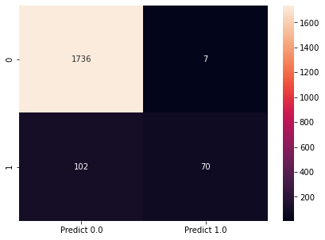

```python
from sklearn.metrics import classification_report,confusion_matrix
mat_train = confusion_matrix( Y_test_b,model.predict(X_test_b),labels=[0.0, 1.0])

df_cm = pd.DataFrame(mat_train, index = [i for i in [0, 1]],
                  columns = [i for i in ["Predict 0.0","Predict 1.0"]])

plt.figure(figsize = (7,5))
from sklearn.metrics import classification_report,confusion_matrix
mat_train = confusion_matrix(Y_test_b,y_predict,labels=[0, 1])

df_cm = pd.DataFrame(mat_train, index = [i for i in [0, 1]],
                  columns = [i for i in ["Predict 0.0","Predict 1.0"]])
plt.figure(figsize = (7,5))
sns.heatmap(df_cm, annot=True,fmt='.4g')
```

### selecting model with best parameter - Naive Bayes Using Grid Search

```python
from sklearn.naive_bayes import BernoulliNB

bernoulli_nb =  BernoulliNB(alpha=0.01)
bernoulli_nb.fit(X_train_b, Y_train_b)
pred = bernoulli_nb.predict(X_test_b)
nb_score_test = bernoulli_nb.score(X_train_b, Y_train_b)
print("Test score Naive Bayes",nb_score_test)
nb_score_train = bernoulli_nb.score(X_train_b, Y_train_b)
print("Train score Naive Bayes",nb_score_train)
print("\n\n\n Classification report for Naive bayes\n\n\n",classification_report(Y_test_b, bernoulli_nb.predict(X_test_b),labels=[0.0,1.0]))
```

```
Test score Naive Bayes 0.9272284122562674
Train score Naive Bayes 0.9272284122562674



 Classification report for Naive bayes


               precision    recall  f1-score   support

         0.0       0.93      0.99      0.96      1743
         1.0       0.73      0.21      0.33       172

    accuracy                           0.92      1915
   macro avg       0.83      0.60      0.64      1915
weighted avg       0.91      0.92      0.90      1915
```

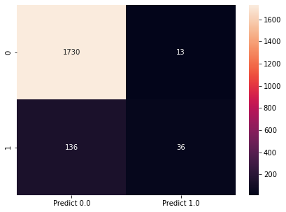

```python
from sklearn.metrics import classification_report,confusion_matrix
mat_train = confusion_matrix(Y_test_b, bernoulli_nb.predict(X_test_b),labels=[0.0, 1.0])

df_cm = pd.DataFrame(mat_train, index = [i for i in [0, 1]],
                  columns = [i for i in ["Predict 0.0","Predict 1.0"]])
plt.figure(figsize = (7,5))
sns.heatmap(df_cm, annot=True,fmt='.4g')
```

```
0.2177869801154351 0.8871255948877915 0.9540420819490587 120 120
```

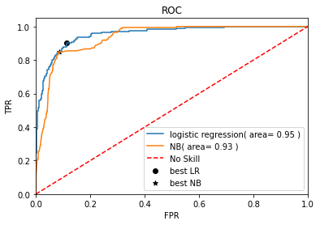

```python
from sklearn.metrics import roc_auc_score
from sklearn.metrics import roc_curve
from numpy import sqrt,argmax
logit_roc_auc = roc_auc_score(Y_test_b,model.predict_proba(X_test_b)[:,1])
nb_roc_auc = roc_auc_score(Y_test_b,bernoulli_nb.predict_proba(X_test_b)[:,1])
fpr,tpr,threshold = roc_curve(Y_test_b,model.predict_proba(X_test_b)[:,1])
fpr1,tpr1,threshold1 = roc_curve(Y_test_b,bernoulli_nb.predict_proba(X_test_b)[:,1])
gmeans = sqrt(tpr*1-fpr)
ix = argmax(gmeans)
ixNB =  argmax(sqrt(tpr1*1-fpr1))
print(threshold[ix],gmeans[ix],logit_roc_auc,ix,argmax(gmeans) )
plt.figure()
plt.plot(fpr,tpr,label = 'logistic regression( area= %0.2f )' % logit_roc_auc)

plt.plot(fpr1,tpr1,label = 'NB( area= %0.2f )' % nb_roc_auc)
plt.plot([0,1],[0,1],'r--',label = 'No Skill')
plt.scatter(fpr[ix],tpr[ix],marker ='o',color = 'black',label ='best LR')
plt.scatter(fpr1[ixNB],tpr1[ixNB],marker ='*',color = 'black',label ='best NB')
plt.xlim([0.0,1.0])
plt.ylim([0.0,1.05])
plt.xlabel("FPR")
plt.ylabel("TPR")
plt.title('ROC')
plt.legend(loc='lower right')
plt.show()
#X_train_b.shape, Y_train_b.shape,X_test_b.shape,Y_test_b.shape
```

It is evident from the plot that the AUC for the Logistic Regression ROC curve is higher than that for the Naive Bayes ROC curve

```
Best threshold = 0.331413, F-score =0.696
```

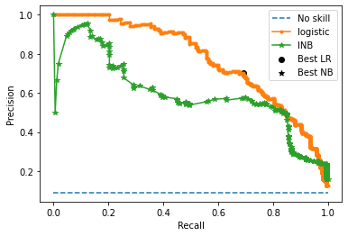

```python
#precison recall
from sklearn.metrics import precision_recall_curve
yht =model.predict_proba(X_test_b)[:,1]

precision,recall,thresholds = precision_recall_curve(Y_test_b,yht)
precision1,recall1,thresholds1 = precision_recall_curve(Y_test_b,bernoulli_nb.predict_proba(X_test_b)[:,1])
fscore = (2*precision*recall)/(precision+recall)
fscoreNB = (2*precision1*recall1)/(precision1+recall1)
ix = argmax(fscore)
ixnb =argmax(fscoreNB)
print('Best threshold = %f, F-score =%.3f'% (thresholds[ix],fscore[ix]))

no_skill = len(Y_test_b[Y_test_b==1])/len(Y_test_b)
plt.plot([0,1],[no_skill,no_skill],linestyle = '--',label='No skill')
plt.plot(recall,precision,marker='.',label='logistic')
plt.plot(recall1,precision1,marker='*',label='lNB')
plt.scatter(recall[ix],precision[ix],marker='o',color = 'black',label='Best LR')
plt.scatter(recall1[ixnb],precision1[ixnb],marker='*',color = 'black',label='Best NB')
plt.xlabel('Recall')
plt.ylabel('Precision')
plt.legend()
plt.show()
```

### Best Model and Why ?

###### Quality